# Dates and Times | r4ds Chapter 16

Biostat 203B

Author

Dr. Hua Zhou @ UCLA

Published

February 7, 2024

## 1 Preamble

Display machine information for reproducibility.

**R**

**Python**

```python
import IPython
print(IPython.sys_info())
```

```
{'commit_hash': 'dc4369111',
 'commit_source': 'installation',
 'default_encoding': 'utf-8',
 'ipython_path': '/opt/venv/lib/python3.10/site-packages/IPython',
 'ipython_version': '8.19.0',
 'os_name': 'posix',
 'platform': 'Linux-6.6.12-linuxkit-aarch64-with-glibc2.35',
 'sys_executable': '/opt/venv/bin/python',
 'sys_platform': 'linux',
 'sys_version': '3.10.12 (main, Nov 20 2023, 15:14:05) [GCC 11.4.0]'}
```

**Julia**

```julia
using InteractiveUtils
versioninfo()
```

```
Julia Version 1.9.4
Commit 8e5136fa297 (2023-11-14 08:46 UTC)
Build Info:
  Official https://julialang.org/ release
Platform Info:
  OS: Linux (aarch64-linux-gnu)
  CPU: 12 × unknown
  WORD_SIZE: 64
  LIBM: libopenlibm
  LLVM: libLLVM-14.0.6 (ORCJIT, generic)
  Threads: 1 on 12 virtual cores
Environment:
  JULIA_PKGDIR = /opt/julia
  JULIA_DEPOT_PATH = /opt/julia
  LD_LIBRARY_PATH = /usr/local/lib/R/lib:/usr/local/lib:/usr/lib/aarch64-linux-gnu:/usr/lib/jvm/java-11-openjdk-arm64/lib/server:/usr/local/lib/R/lib:/lib:/usr/local/lib:/usr/lib/aarch64-linux-gnu:/usr/lib/jvm/java-11-openjdk-arm64/lib/server
```

Load tidyverse and lubridate (R), Pandas (Python), and DataFrames.jl (Julia).

**R**

```r
library(lubridate)
library(nycflights13)
library(tidyverse)
```

**Python**

```python
# Load the pandas library
import pandas as pd
# Load numpy for array manipulation
import numpy as np
```

**Julia**

```julia
using DataFrames, Pipe, StatsBase
```

## 2 Basics

Three types of data/time data:

- **date**. Tibbles print it as `<date>`.
- **time**. Tibbles print it as `<time>`.
- **date-time**. Tibbles print it as `<dttm>`.

In the `flights` tibble, the last variable `time_hour` is in the data-time format:

**R**

```r
flights |> print(width = Inf)
```

```
# A tibble: 336,776 × 19
    year month   day dep_time sched_dep_time dep_delay arr_time sched_arr_time
   <int> <int> <int>    <int>          <int>     <dbl>    <int>          <int>
 1  2013     1     1      517            515         2      830            819
 2  2013     1     1      533            529         4      850            830
 3  2013     1     1      542            540         2      923            850
 4  2013     1     1      544            545        -1     1004           1022
 5  2013     1     1      554            600        -6      812            837
 6  2013     1     1      554            558        -4      740            728
 7  2013     1     1      555            600        -5      913            854
 8  2013     1     1      557            600        -3      709            723
 9  2013     1     1      557            600        -3      838            846
10  2013     1     1      558            600        -2      753            745
   arr_delay carrier flight tailnum origin dest  air_time distance  hour minute
       <dbl> <chr>    <int> <chr>   <chr>  <chr>    <dbl>    <dbl> <dbl>  <dbl>
```

[output cut: 23 more lines]

**Python**

The nycflights13 data is available from the nycflights13 package in Python.

```python
from nycflights13 import flights

flights
```

```
        year  month  day  ...  hour  minute             time_hour
0       2013      1    1  ...     5      15  2013-01-01T10:00:00Z
1       2013      1    1  ...     5      29  2013-01-01T10:00:00Z
2       2013      1    1  ...     5      40  2013-01-01T10:00:00Z
3       2013      1    1  ...     5      45  2013-01-01T10:00:00Z
4       2013      1    1  ...     6       0  2013-01-01T11:00:00Z
...      ...    ...  ...  ...   ...     ...                   ...
336771  2013      9   30  ...    14      55  2013-09-30T18:00:00Z
336772  2013      9   30  ...    22       0  2013-10-01T02:00:00Z
336773  2013      9   30  ...    12      10  2013-09-30T16:00:00Z
336774  2013      9   30  ...    11      59  2013-09-30T15:00:00Z
336775  2013      9   30  ...     8      40  2013-09-30T12:00:00Z

[336776 rows x 19 columns]
```

Note there are some differences of this `flights` data from that in tidyverse. The data types for some variables are different. There are no natural ways in Pandas to hold integer column with missing values; so `dep_time` , `arr_time` are `float64` instead of `int64`.

```python
flights.info()
```

```
<class 'pandas.core.frame.DataFrame'>
RangeIndex: 336776 entries, 0 to 336775
Data columns (total 19 columns):
 #   Column          Non-Null Count   Dtype
---  ------          --------------   -----
 0   year            336776 non-null  int64
 1   month           336776 non-null  int64
 2   day             336776 non-null  int64
 3   dep_time        328521 non-null  float64
 4   sched_dep_time  336776 non-null  int64
 5   dep_delay       328521 non-null  float64
 6   arr_time        328063 non-null  float64
 7   sched_arr_time  336776 non-null  int64
 8   arr_delay       327346 non-null  float64
 9   carrier         336776 non-null  object
 10  flight          336776 non-null  int64
 11  tailnum         334264 non-null  object
 12  origin          336776 non-null  object
 13  dest            336776 non-null  object
 14  air_time        327346 non-null  float64
 15  distance        336776 non-null  int64
 16  hour            336776 non-null  int64
 17  minute          336776 non-null  int64
 18  time_hour       336776 non-null  object
dtypes: float64(5), int64(9), object(5)
memory usage: 48.8+ MB
```

To be more consistent with `nycflights13` in tidyverse, we cast `time_hour` to `datetime` type.

```python
flights['time_hour'] = pd.to_datetime(flights['time_hour'])
```

**Julia**

Let’s use RCall.jl to retrieve the nycflights13 data from R.

```julia
using RCall

R"""
library(nycflights13)
"""
```

```
RObject{StrSxp}
```

```julia
flights = rcopy(R"flights")
```

```
336776×19 DataFrame
    Row │ year   month  day    dep_time  sched_dep_time  dep_delay  arr_time   ⋯
        │ Int64  Int64  Int64  Int64?    Int64           Float64?   Int64?     ⋯
────────┼───────────────────────────────────────────────────────────────────────
      1 │  2013      1      1       517             515        2.0       830   ⋯
      2 │  2013      1      1       533             529        4.0       850
      3 │  2013      1      1       542             540        2.0       923
      4 │  2013      1      1       544             545       -1.0      1004
      5 │  2013      1      1       554             600       -6.0       812   ⋯
      6 │  2013      1      1       554             558       -4.0       740
      7 │  2013      1      1       555             600       -5.0       913
      8 │  2013      1      1       557             600       -3.0       709
   ⋮    │   ⋮      ⋮      ⋮       ⋮            ⋮             ⋮         ⋮       ⋱
 336770 │  2013      9     30      2349            2359      -10.0       325   ⋯
 336771 │  2013      9     30   missing            1842  missing     missing
 336772 │  2013      9     30   missing            1455  missing     missing
 336773 │  2013      9     30   missing            2200  missing     missing
 336774 │  2013      9     30   missing            1210  missing     missing   ⋯
 336775 │  2013      9     30   missing            1159  missing     missing
 336776 │  2013      9     30   missing             840  missing     missing
                                              12 columns and 336761 rows omitted
```

## 3 Create date/times

### 3.1 `today` and `now`

**R**

Today:

```r
# current date
today()
```

```
[1] "2024-02-07"
```

```r
# current date-time
now()
```

```
[1] "2024-02-07 23:48:00 UTC"
```

**Python**

Today:

```python
from datetime import date, datetime

# Current date
date.today()
```

```
datetime.date(2024, 2, 7)
```

```python
# Current date-time
datetime.now()
```

```
datetime.datetime(2024, 2, 7, 23, 48, 0, 987348)
```

**Julia**

```julia
using Dates
# Current date
today()
```

```
2024-02-07
```

```julia
# Current date-time
now()
```

```
2024-02-07T23:48:01.125
```

### 3.2 From strings

**R**

```r
ymd("2023-02-02")
```

```
[1] "2023-02-02"
```

```r
mdy("Feb 2nd, 2023")
```

```
[1] "2023-02-02"
```

```r
dmy("02-Feb-2023")
```

```
[1] "2023-02-02"
```

```r
# default time zone is UTC
ymd_hms("2023-02-02 14:57:25")
```

```
[1] "2023-02-02 14:57:25 UTC"
```

```r
ymd_hm("2023-02-02 14:57")
```

```
[1] "2023-02-02 14:57:00 UTC"
```

**Python**

```python
from dateutil.parser import parse

datetime.strptime('2023-02-02', '%Y-%m-%d').date()
```

```
datetime.date(2023, 2, 2)
```

```python
# I have to use the package python-dateutils to parse Feb 2nd
parse('Feb 2nd, 2023').date()
```

```
datetime.date(2023, 2, 2)
```

```python
datetime.strptime('02-Feb-2023', '%d-%b-%Y').date()
```

```
datetime.date(2023, 2, 2)
```

```python
datetime.strptime('2023-02-02 14:57:25', '%Y-%m-%d %H:%M:%S')
```

```
datetime.datetime(2023, 2, 2, 14, 57, 25)
```

```python
datetime.strptime('2023-02-02 14:57', '%Y-%m-%d %H:%M')
```

```
datetime.datetime(2023, 2, 2, 14, 57)
```

**Julia**

```julia
Date("2023-02-02", dateformat"y-m-d")
```

```
2023-02-02
```

```julia
# Not sure how to parse "Feb 2nd, 2023" ???
# Date("Feb 2nd, 2023", dateformat"u d, y")
Date("02-Feb-2023", dateformat"d-u-y")
```

```
2023-02-02
```

```julia
DateTime("2023-02-02 14:57:25", dateformat"y-m-d H:M:S")
```

```
2023-02-02T14:57:25
```

```julia
DateTime("2023-02-02 14:57", dateformat"y-m-d H:M")
```

```
2023-02-02T14:57:00
```

### 3.3 From unquoated numbers

**R**

```r
ymd(20200202)
```

```
[1] "2020-02-02"
```

**Python**

```python
datetime(2022, 2, 2).date()
```

```
datetime.date(2022, 2, 2)
```

**Julia**

```julia
Date(2020, 2, 2)
```

```
2020-02-02
```

### 3.4 From variables/columns in a tibble

**R**

```r
flights |>
  select(year, month, day, hour, minute) |>
  mutate(departure = make_datetime(year, month, day, hour, minute))
```

```
# A tibble: 336,776 × 6
    year month   day  hour minute departure
   <int> <int> <int> <dbl>  <dbl> <dttm>
 1  2013     1     1     5     15 2013-01-01 05:15:00
 2  2013     1     1     5     29 2013-01-01 05:29:00
 3  2013     1     1     5     40 2013-01-01 05:40:00
 4  2013     1     1     5     45 2013-01-01 05:45:00
 5  2013     1     1     6      0 2013-01-01 06:00:00
 6  2013     1     1     5     58 2013-01-01 05:58:00
 7  2013     1     1     6      0 2013-01-01 06:00:00
 8  2013     1     1     6      0 2013-01-01 06:00:00
 9  2013     1     1     6      0 2013-01-01 06:00:00
10  2013     1     1     6      0 2013-01-01 06:00:00
# ℹ 336,766 more rows
```

```r
make_datetime_100 <- function(year, month, day, time) {
  make_datetime(year, month, day, time %/% 100, time %% 100)
}

flights_dt <- flights |>
  filter(!is.na(dep_time), !is.na(arr_time)) |>
  mutate(
    dep_time = make_datetime_100(year, month, day, dep_time),
    arr_time = make_datetime_100(year, month, day, arr_time),
    sched_dep_time = make_datetime_100(year, month, day, sched_dep_time),
    sched_arr_time = make_datetime_100(year, month, day, sched_arr_time)
  ) |>
  select(origin, dest, ends_with("delay"), ends_with("time")) |>
  print(width = Inf)
```

```
# A tibble: 328,063 × 9
   origin dest  dep_delay arr_delay dep_time            sched_dep_time
   <chr>  <chr>     <dbl>     <dbl> <dttm>              <dttm>
 1 EWR    IAH           2        11 2013-01-01 05:17:00 2013-01-01 05:15:00
 2 LGA    IAH           4        20 2013-01-01 05:33:00 2013-01-01 05:29:00
 3 JFK    MIA           2        33 2013-01-01 05:42:00 2013-01-01 05:40:00
 4 JFK    BQN          -1       -18 2013-01-01 05:44:00 2013-01-01 05:45:00
 5 LGA    ATL          -6       -25 2013-01-01 05:54:00 2013-01-01 06:00:00
 6 EWR    ORD          -4        12 2013-01-01 05:54:00 2013-01-01 05:58:00
 7 EWR    FLL          -5        19 2013-01-01 05:55:00 2013-01-01 06:00:00
 8 LGA    IAD          -3       -14 2013-01-01 05:57:00 2013-01-01 06:00:00
 9 JFK    MCO          -3        -8 2013-01-01 05:57:00 2013-01-01 06:00:00
10 LGA    ORD          -2         8 2013-01-01 05:58:00 2013-01-01 06:00:00
   arr_time            sched_arr_time      air_time
   <dttm>              <dttm>                 <dbl>
 1 2013-01-01 08:30:00 2013-01-01 08:19:00      227
 2 2013-01-01 08:50:00 2013-01-01 08:30:00      227
 3 2013-01-01 09:23:00 2013-01-01 08:50:00      160
 4 2013-01-01 10:04:00 2013-01-01 10:22:00      183
 5 2013-01-01 08:12:00 2013-01-01 08:37:00      116
 6 2013-01-01 07:40:00 2013-01-01 07:28:00      150
 7 2013-01-01 09:13:00 2013-01-01 08:54:00      158
 8 2013-01-01 07:09:00 2013-01-01 07:23:00       53
 9 2013-01-01 08:38:00 2013-01-01 08:46:00      140
10 2013-01-01 07:53:00 2013-01-01 07:45:00      138
# ℹ 328,053 more rows
```

Now we can visualize the distribution of departure times across the year

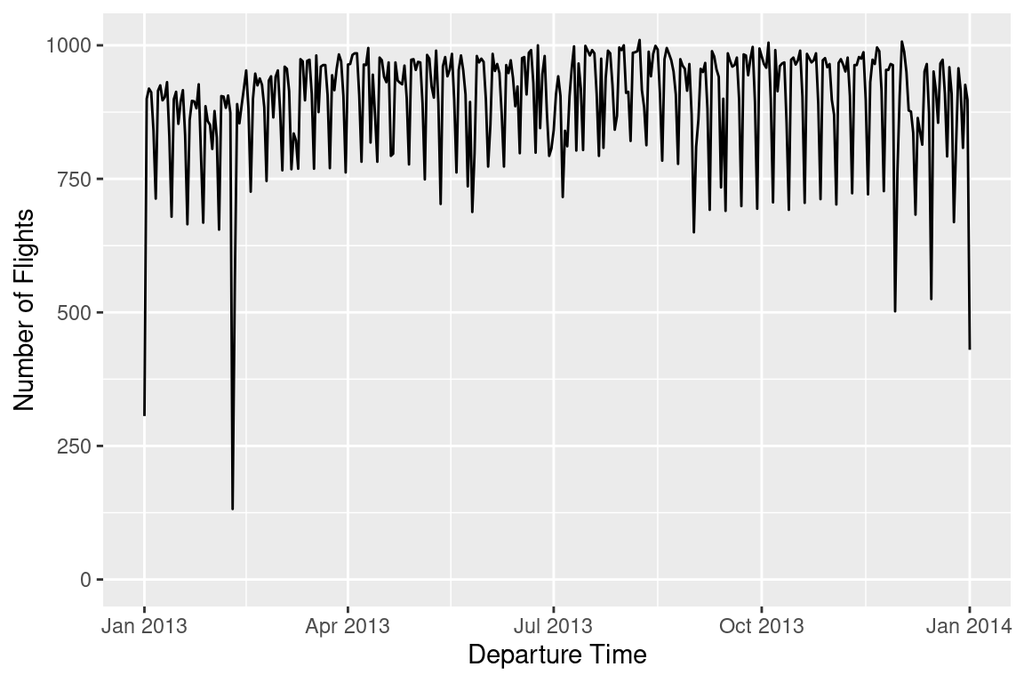

```r
flights_dt |>
  ggplot(aes(x = dep_time)) +
  geom_freqpoly(binwidth = 86400) + # 86400 seconds = 1 day
  labs(
    x = "Departure Time",
    y = "Number of Flights"
  ) +
  xlim(
    ymd_hms("2013-01-01 00:00:00"),
    ymd_hms("2014-01-01 00:00:00")
    )
```

or within a single day:

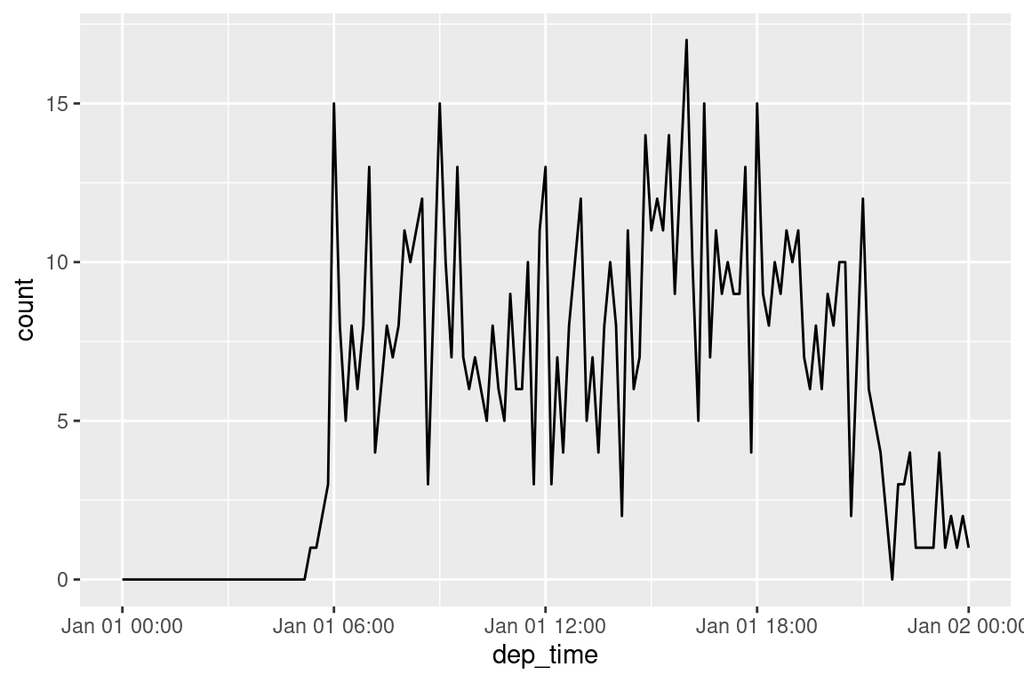

```r
flights_dt |>
  filter(dep_time < ymd(20130102)) |>
  ggplot(aes(dep_time)) +
  geom_freqpoly(binwidth = 600) + # 600 s = 10 minutes
  xlim(
    ymd_hms("2013-01-01 00:00:00"),
    ymd_hms("2013-01-02 00:00:00")
    )
```

**Python**

**Julia**

## 4 Getting components

```r
datetime <- ymd_hms("2023-02-02 15:34:56")
year(datetime)
```

```
[1] 2023
```

```r
month(datetime)
```

```
[1] 2
```

```r
mday(datetime)
```

```
[1] 2
```

```r
yday(datetime)
```

```
[1] 33
```

```r
wday(datetime)
```

```
[1] 5
```

More information in `month()` and `wday()`:

```r
month(datetime, label = TRUE, abbr = FALSE)
```

```
[1] February
12 Levels: January < February < March < April < May < June < ... < December
```

```r
wday(datetime, label = TRUE, abbr = FALSE)
```

```
[1] Thursday
7 Levels: Sunday < Monday < Tuesday < Wednesday < Thursday < ... < Saturday
```

Visualize number of departures during a week:

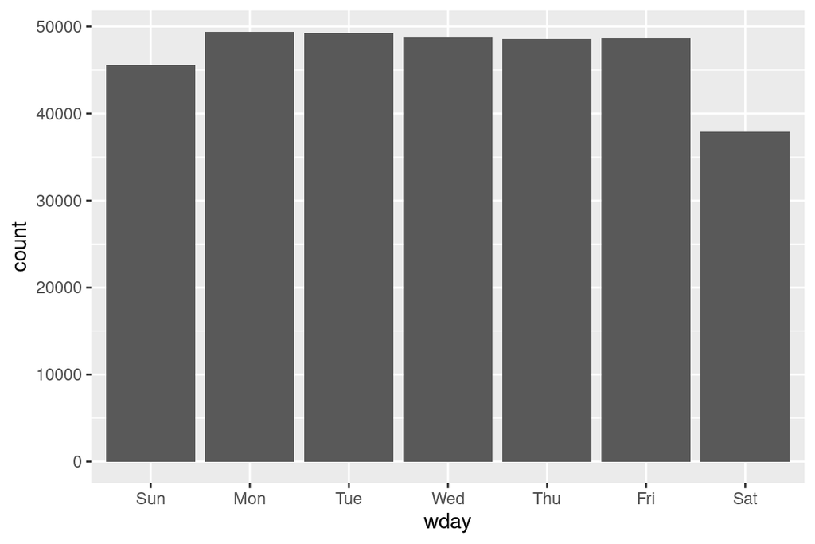

```r
flights_dt |>
  mutate(wday = wday(dep_time, label = TRUE)) |>
  ggplot(aes(x = wday)) +
  geom_bar()
```

## 5 Rounding

`floor_date()`, `round_date()`, `ceiling_date()`:

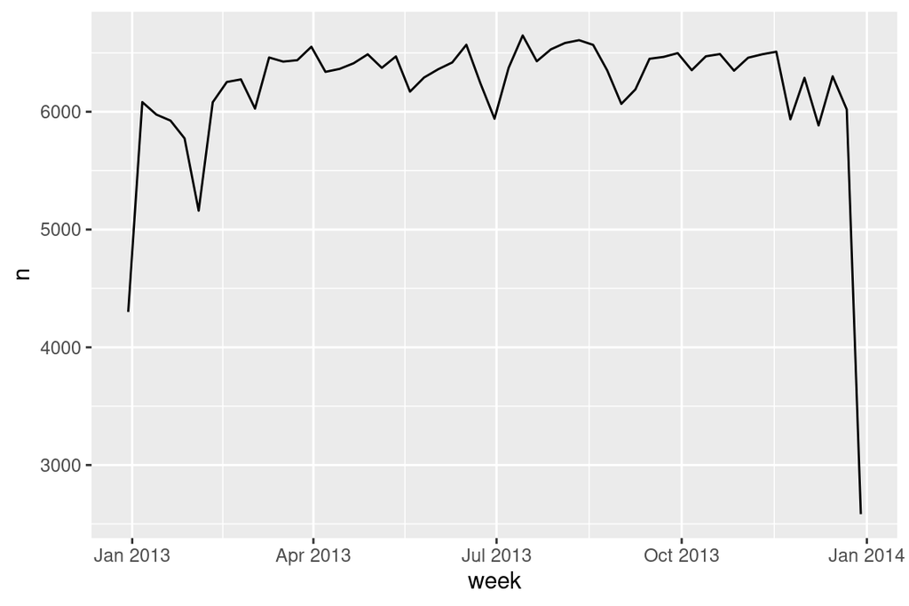

```r
flights_dt |>
  count(week = floor_date(dep_time, "week")) |>
  ggplot(aes(x = week, y = n)) +
  geom_line()
```

## 6 Time spans

### 6.1 Durations

Substract two dates we get a `difftime` object:

```r
# How old is Hadley?
h_age <- today() - ymd(19791014)
h_age
```

```
Time difference of 16187 days
```

lubridate provides the **duration** object that always uses seconds:

```r
as.duration(h_age)
```

```
[1] "1398556800s (~44.32 years)"
```

Constructors for duration:

```r
dseconds(5)
```

```
[1] "5s"
```

```r
dminutes(10)
```

```
[1] "600s (~10 minutes)"
```

```r
dhours(c(12, 24))
```

```
[1] "43200s (~12 hours)" "86400s (~1 days)"
```

```r
ddays(0:5)
```

```
[1] "0s"                "86400s (~1 days)"  "172800s (~2 days)"
[4] "259200s (~3 days)" "345600s (~4 days)" "432000s (~5 days)"
```

```r
dweeks(3)
```

```
[1] "1814400s (~3 weeks)"
```

```r
dyears(1)
```

```
[1] "31557600s (~1 years)"
```

### 6.2 Periods

Durations represent an exact number of seconds:

```r
one_pm <- ymd_hms("2016-03-12 13:00:00", tz = "America/New_York")
one_pm
```

```
[1] "2016-03-12 13:00:00 EST"
```

```r
one_pm + ddays(1)
```

```
[1] "2016-03-13 14:00:00 EDT"
```

Periods are time spans but don’t have a fixed length in seconds, instead they work with “human” times, like days and months.

```r
one_pm
```

```
[1] "2016-03-12 13:00:00 EST"
```

```r
one_pm + days(1)
```

```
[1] "2016-03-13 13:00:00 EDT"
```

Constructors for period:

```r
seconds(15)
```

```
[1] "15S"
```

```r
minutes(10)
```

```
[1] "10M 0S"
```

```r
hours(c(12, 24))
```

```
[1] "12H 0M 0S" "24H 0M 0S"
```

```r
days(7)
```

```
[1] "7d 0H 0M 0S"
```

```r
months(1:6)
```

```
[1] "1m 0d 0H 0M 0S" "2m 0d 0H 0M 0S" "3m 0d 0H 0M 0S" "4m 0d 0H 0M 0S"
[5] "5m 0d 0H 0M 0S" "6m 0d 0H 0M 0S"
```

```r
weeks(3)
```

```
[1] "21d 0H 0M 0S"
```

```r
years(1)
```

```
[1] "1y 0m 0d 0H 0M 0S"
```

Some planes appear to have arrived at their destination before they departed from New York City.

```r
flights_dt |>
  filter(arr_time < dep_time) |>
  print(width = Inf)
```

```
# A tibble: 10,633 × 9
   origin dest  dep_delay arr_delay dep_time            sched_dep_time
   <chr>  <chr>     <dbl>     <dbl> <dttm>              <dttm>
 1 EWR    BQN           9        -4 2013-01-01 19:29:00 2013-01-01 19:20:00
 2 JFK    DFW          59        NA 2013-01-01 19:39:00 2013-01-01 18:40:00
 3 EWR    TPA          -2         9 2013-01-01 20:58:00 2013-01-01 21:00:00
 4 EWR    SJU          -6       -12 2013-01-01 21:02:00 2013-01-01 21:08:00
 5 EWR    SFO          11       -14 2013-01-01 21:08:00 2013-01-01 20:57:00
 6 LGA    FLL         -10        -2 2013-01-01 21:20:00 2013-01-01 21:30:00
 7 EWR    MCO          41        43 2013-01-01 21:21:00 2013-01-01 20:40:00
 8 JFK    LAX          -7       -24 2013-01-01 21:28:00 2013-01-01 21:35:00
 9 EWR    FLL          49        28 2013-01-01 21:34:00 2013-01-01 20:45:00
10 EWR    FLL          -9       -14 2013-01-01 21:36:00 2013-01-01 21:45:00
   arr_time            sched_arr_time      air_time
   <dttm>              <dttm>                 <dbl>
 1 2013-01-01 00:03:00 2013-01-01 00:07:00      192
 2 2013-01-01 00:29:00 2013-01-01 21:51:00       NA
 3 2013-01-01 00:08:00 2013-01-01 23:59:00      159
 4 2013-01-01 01:46:00 2013-01-01 01:58:00      199
 5 2013-01-01 00:25:00 2013-01-01 00:39:00      354
 6 2013-01-01 00:16:00 2013-01-01 00:18:00      160
 7 2013-01-01 00:06:00 2013-01-01 23:23:00      143
 8 2013-01-01 00:26:00 2013-01-01 00:50:00      338
 9 2013-01-01 00:20:00 2013-01-01 23:52:00      152
10 2013-01-01 00:25:00 2013-01-01 00:39:00      154
# ℹ 10,623 more rows
```

These are the overnight flights. Let’s fix this:

```r
flights_dt <- flights_dt |>
  mutate(
    overnight = arr_time < dep_time,
    arr_time = arr_time + days(overnight * 1),
    sched_arr_time = sched_arr_time + days(overnight * 1)
  ) |>
  print(width = Inf)
```

```
# A tibble: 328,063 × 10
   origin dest  dep_delay arr_delay dep_time            sched_dep_time
   <chr>  <chr>     <dbl>     <dbl> <dttm>              <dttm>
 1 EWR    IAH           2        11 2013-01-01 05:17:00 2013-01-01 05:15:00
 2 LGA    IAH           4        20 2013-01-01 05:33:00 2013-01-01 05:29:00
 3 JFK    MIA           2        33 2013-01-01 05:42:00 2013-01-01 05:40:00
 4 JFK    BQN          -1       -18 2013-01-01 05:44:00 2013-01-01 05:45:00
 5 LGA    ATL          -6       -25 2013-01-01 05:54:00 2013-01-01 06:00:00
 6 EWR    ORD          -4        12 2013-01-01 05:54:00 2013-01-01 05:58:00
 7 EWR    FLL          -5        19 2013-01-01 05:55:00 2013-01-01 06:00:00
 8 LGA    IAD          -3       -14 2013-01-01 05:57:00 2013-01-01 06:00:00
 9 JFK    MCO          -3        -8 2013-01-01 05:57:00 2013-01-01 06:00:00
10 LGA    ORD          -2         8 2013-01-01 05:58:00 2013-01-01 06:00:00
   arr_time            sched_arr_time      air_time overnight
   <dttm>              <dttm>                 <dbl> <lgl>
 1 2013-01-01 08:30:00 2013-01-01 08:19:00      227 FALSE
 2 2013-01-01 08:50:00 2013-01-01 08:30:00      227 FALSE
 3 2013-01-01 09:23:00 2013-01-01 08:50:00      160 FALSE
 4 2013-01-01 10:04:00 2013-01-01 10:22:00      183 FALSE
 5 2013-01-01 08:12:00 2013-01-01 08:37:00      116 FALSE
 6 2013-01-01 07:40:00 2013-01-01 07:28:00      150 FALSE
 7 2013-01-01 09:13:00 2013-01-01 08:54:00      158 FALSE
 8 2013-01-01 07:09:00 2013-01-01 07:23:00       53 FALSE
 9 2013-01-01 08:38:00 2013-01-01 08:46:00      140 FALSE
10 2013-01-01 07:53:00 2013-01-01 07:45:00      138 FALSE
# ℹ 328,053 more rows
```

### 6.3 Intervals

Intervals are time spans bound by two real date-times. Intervals can be accurately converted to periods and durations.

```r
interval(ymd_hms("2009-08-09 13:01:30"), ymd_hms("2009-08-09 12:00:00"))
```

```
[1] 2009-08-09 13:01:30 UTC--2009-08-09 12:00:00 UTC
```

```r
date <- ymd_hms("2009-03-08 01:59:59") # DST boundary
date2 <- ymd_hms("2000-02-29 12:00:00")
span <- date2 %--% date
as.duration(span)
```

```
[1] "284651999s (~9.02 years)"
```

```r
as.period(span)
```

```
[1] "9y 0m 7d 13H 59M 59S"
```

## 7 Cheat sheet

[Posit cheat sheet](https://rstudio.github.io/cheatsheets/html/lubridate.html) is extremely useful.